# Report about breast cancer in Poland

D. Bottoli, P. Dycha, K. Gajewska, A. Gasiorowski  
18/05/2016

### Dataset description

- Our dataset consists in observations about the presence of **breast cancer** in the polish population.
- There are variables reguarding characteristics of the population as **gender**, **age range**, the location detection as **TERYT**, **region**, **subregion** and the amount of new cancer in the respective phases as **year**, **stage 1**, **stage 2**, **stage 3**, **stage 4** and **new**.
- Let's have a first look on the relation between the number of *cancers*, *gender*, *year* and *age range*

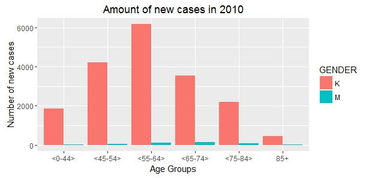

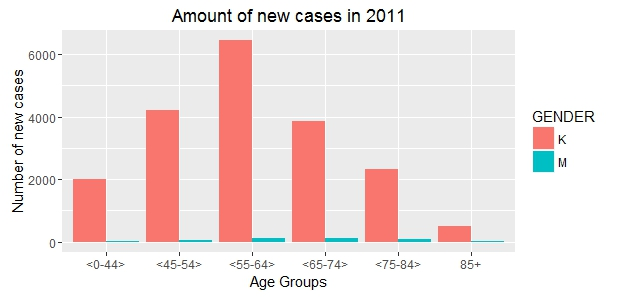

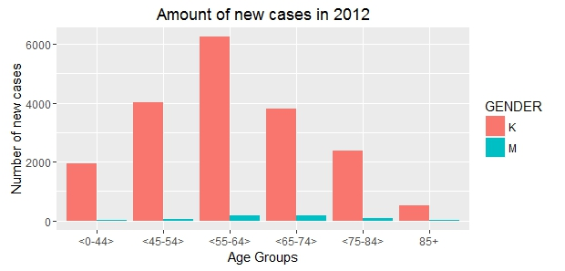

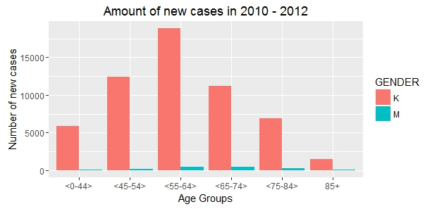

### Comment #1

1. This type of cancer is much more present in the females than in the males.
2. The amount of new cancers detected is approximately constant in the tree years of the analysis.
3. The distriubutions have a bell shape but we must take into consideration the amount of the population in each of the age range.  
   Considering that the curve of the age is decreasing, the proportion of people stricken by the disease is firstly increasing, then constant.

Now let us look at the differences between means of the stages between voivodeships.

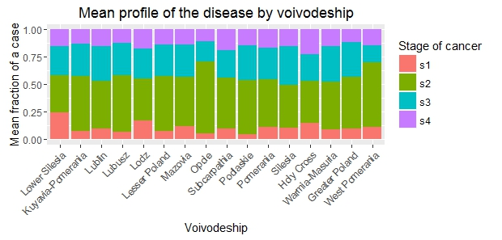

Thank you for the attention